# Generates negative binomial data

```r
library(ggplot2)
library(colormap)
library(cmdstanr)
library(posterior)
library(dplyr)
```

```r
# we recommend running this is a fresh R session or restarting your current session
#("cmdstanr", repos = c("https://mc-stan.org/r-packages/", getOption("repos")))
```

```r
# Installing to my cloud backup drive didn't work
#install_cmdstan(dir = 'C:\\stan')
#rebuild_cmdstan()

# check everything is fine with the compilation toolchain
check_cmdstan_toolchain()
```

```
The CmdStan toolchain is setup properly!
```

```r
# if necessary, install cmdstan
```

```r
cmdstan_path()
```

```
[1] "C:/stan/cmdstan-2.26.1"
```

```r
cmdstan_version()
```

```
[1] "2.26.1"
```

Set up some default colours for use later.

```r
c_light <- c("#DCBCBC")
c_light_highlight <- c("#C79999")
c_mid <- c("#B97C7C")
c_mid_highlight <- c("#A25050")
c_dark <- c("#8F2727")
c_dark_highlight <- c("#7C0000")

nom_colors <- c("#DCBCBC", "#C79999", "#B97C7C", "#A25050", "#8F2727", "#7C0000")

c_light_teal <- c("#6B8E8E")
c_mid_teal <- c("#487575")
c_dark_teal <- c("#1D4F4F")
```

# Generate the mean and overdispersion processes

We generate some data, where the mean and overdispersion vary over time.

Both the mean and overdispersion are modelled using the exponent of a random walk process (since we want strictly positive values. We then plug these into a Stan model to generate some negative binomial count data. Since we use a Stan model to estimate the underlying process later, it makes sense to generate the negative binomial data using a Stan model, so that the parameterisation of the negative binomial doesn’t change.

```r
set.seed(1)
T = 100                 # length of time we observe the process over
x = seq(1, T)           # 1,2,3...,T
mu = exp(2 + cumsum(rnorm(T, 0, 0.05))) # exponentiated random walk
phi = exp(cumsum(rnorm(T, 0, 0.15)))    # exponentiated random walk
```

## Mean process

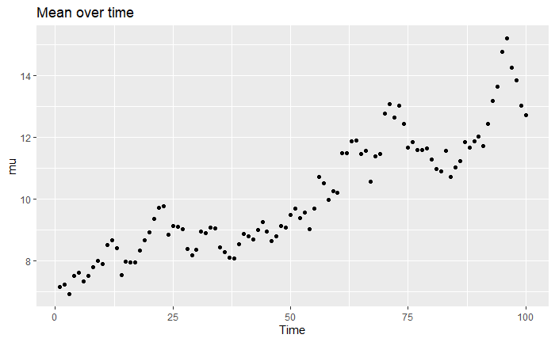

```r
qplot(x, mu) + ggtitle("Mean over time") + xlab("Time")
```

# Overdispersion process

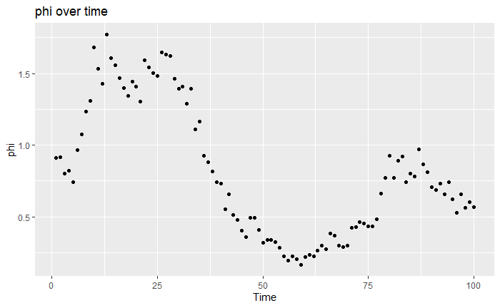

```r
qplot(x, phi) + ggtitle("phi over time") + xlab("Time")
```

# observations per time point

We allow multiple observations of the negative binomial process at each time point. Each day, the number of observations is drawn from a poisson(10) distribution

```r
obs_each_day = rpois(T, 10)
```

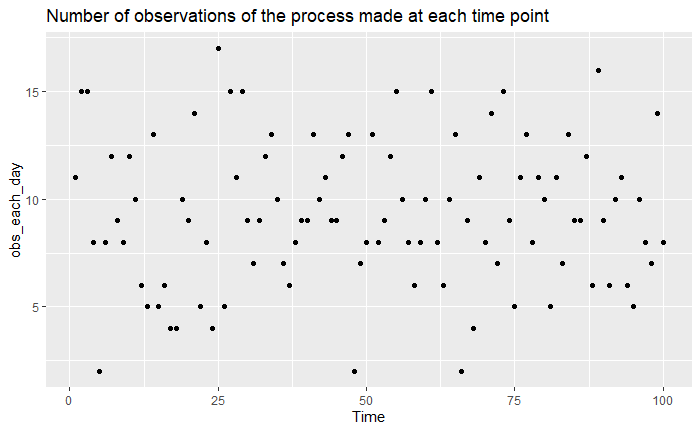

```r
qplot(1:T, obs_each_day) +
  ggtitle('Number of observations of the process made at each time point') +
  xlab('Time')
```

We create a design matrix

```r
time_of_observation = rep(1:T, obs_each_day)
X = model.matrix( ~ as.factor(time_of_observation) - 1) # design matrix
N = length(time_of_observation) # total number of observations
```

We write a stan program that can generate the negative binomial data. This command will recompile if needed.

```r
generate_negative_binomial_process = cmdstan_model('../StanPrograms/SimNegBinProcess.stan')
```

[output not shown]

[output cut: 109 more lines]

[output not shown]

Print the model code so you can see what it does. Should be straightforward to understand - the design matrix describes which observations occur on which day.

```r
generate_negative_binomial_process$print()
```

```
data {
  int<lower=1> T;  // length of time we observe the process over
  int<lower=1> N;  // number of observations
  matrix[N, T] X;  // design matrix
  vector[T] mu;    // mean over time
  vector[T] phi;   // overdispersion over time
}

transformed data {
  vector[N] mu_pred = X * mu;  // predictor vector
  vector[N] phi_pred = X * phi;// predictor vector
}

parameters {
}

transformed parameters {
}

model {
}

generated quantities {
  // generate some negative binomial data
  // This is the formulation with multiple observations per time period
  int y_obs[N] = neg_binomial_2_rng(mu_pred, phi_pred);

  // generate some samples we can use to describe the credible intervals
  // this is the formulation with only a single obs per time point
  int y[T] = neg_binomial_2_rng(mu, phi);
}
```

Set up a list of our inputs

```r
data_in = list(
  mu = mu,
  phi = phi,
  T = T,
  N = N,
  X = X
)
```

Run Stan to generate some data

```r
simulated_data = generate_negative_binomial_process$sample(
  data = data_in,
  fixed_param = TRUE,
  chains = 1,
  seed = 1
)
```

```
Running MCMC with 1 chain...

Chain 1 Iteration:   1 / 1000 [  0%]  (Sampling)
Chain 1 Iteration: 100 / 1000 [ 10%]  (Sampling)
Chain 1 Iteration: 200 / 1000 [ 20%]  (Sampling)
Chain 1 Iteration: 300 / 1000 [ 30%]  (Sampling)
Chain 1 Iteration: 400 / 1000 [ 40%]  (Sampling)
Chain 1 Iteration: 500 / 1000 [ 50%]  (Sampling)
Chain 1 Iteration: 600 / 1000 [ 60%]  (Sampling)
Chain 1 Iteration: 700 / 1000 [ 70%]  (Sampling)
Chain 1 Iteration: 800 / 1000 [ 80%]  (Sampling)
Chain 1 Iteration: 900 / 1000 [ 90%]  (Sampling)
Chain 1 Iteration: 1000 / 1000 [100%]  (Sampling)
Chain 1 finished in 1.1 seconds.
```

Extract some outputs. Everything gets returned as a big dataframe

```r
draws_df = as_draws_df(simulated_data$draws())

draws_y_obs = draws_df %>%
  select(starts_with('y_obs'))
```

```
Dropping 'draws_df' class as required metadata was removed.
```

```r
draws_y = draws_df %>%
  select(starts_with('y['))
```

```
Dropping 'draws_df' class as required metadata was removed.
```

Inspect the first observation of this process. We will save this data, and later fit a model to it to try and estimate the mean and overdispersion process.

# Observed data

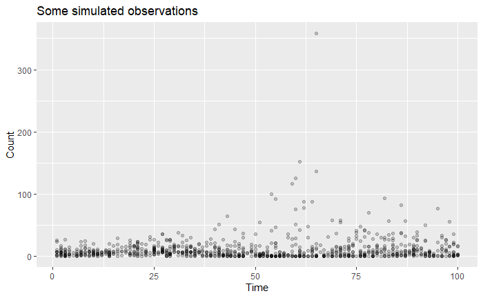

```r
y_obs = as.numeric(draws_y_obs[1,])
qplot(time_of_observation, y_obs, alpha = I(0.2)) +
  ggtitle("Some simulated observations") +
  xlab('Time') +
  ylab('Count')
```

```r
simulated_data = data.frame(time_of_observation, y_obs)
```

```r
write.csv(simulated_data, file = '../Outputs/SimulatedNegBinData.csv')
```

# Credible intervals

We plot the credible intervals from the neagtive binomial process defined by the mean and overdispersion process we randomly generated above.

```r
draws_y_matrix = as.matrix(draws_y)

x_vals = 1:100

probs = c(0.1, 0.2, 0.3, 0.4, 0.5, 0.6, 0.7, 0.8, 0.9)
cred <- sapply(1:100,
               function(n) quantile((draws_y_matrix[,n]), probs=probs))

plot(1, type="n", main='Negative binomial process pdf',
     xlab="x", ylab="f", xlim=c(min(1), max(100)), ylim = c(0, 40))

polygon(c(x_vals, rev(x_vals)), c(cred[1,], rev(cred[9,])),
        col = c_light, border = NA)
```

```r
polygon(c(x_vals, rev(x_vals)), c(cred[2,], rev(cred[8,])),
        col = c_light_highlight, border = NA)
polygon(c(x_vals, rev(x_vals)), c(cred[3,], rev(cred[7,])),
        col = c_mid, border = NA)
```

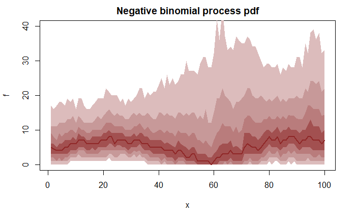

```r
polygon(c(x_vals, rev(x_vals)), c(cred[4,], rev(cred[6,])),
        col = c_mid_highlight, border = NA)
lines(x_vals, cred[5,], col=c_dark, lwd=2)
```